# Data Visualization in R

### Adding custom axes with the axis() function

Typical base graphics functions like boxplot() provide x- and y-axes by default, with a label for the x-axis below the plot and one for the y-axis label to the left of the plot. These labels are generated automatically from the variable names used to generate the plot. Sometimes, we want to provide our own axes labels, and R makes this possible in two steps: first, we suppress the default axes when we create the plot by specifying axes = FALSE; then, we call the low-level graphics function axis() to create the axes we want.

In this exercise, you’re asked to create your own labels using the axis() function with the side, at, and labels arguments. The side argument tells the function which axis to create: a value of 1 adds an axis below the plot; 2 adds an axis on the left; 3 puts it across the top; and 4 puts it on the right side. The second argument, at, is a vector that defines points where tick-marks will be drawn on the axis. The third argument, labels, is a vector that defines labels at each of these tick-marks.

One example of a boxplot with custom axes was presented in the video. This exercise asks you to create another example showing the relationship between the sugars variable and the shelf variable from the UScereal data frame in the MASS package.

### INSTRUCTIONS

Use the boxplot() function to create a boxplot of sugars vs. shelf from the UScereal data frame in the MASS package, with axes suppressed. Use the axis() function with the side parameter specified to add a y-axis label to the left of the box plot showing the range of sugars values. In your second call to axis(), add an x-axis label on the bottom side and specify the at parameter to add tick-marks at the numerical shelf values labelled 1, 2, and 3. In your third call to axis(), add another x-axis label at the top and specify the labels parameter to show the physical shelf locations (“floor”, “middle”, “top”).

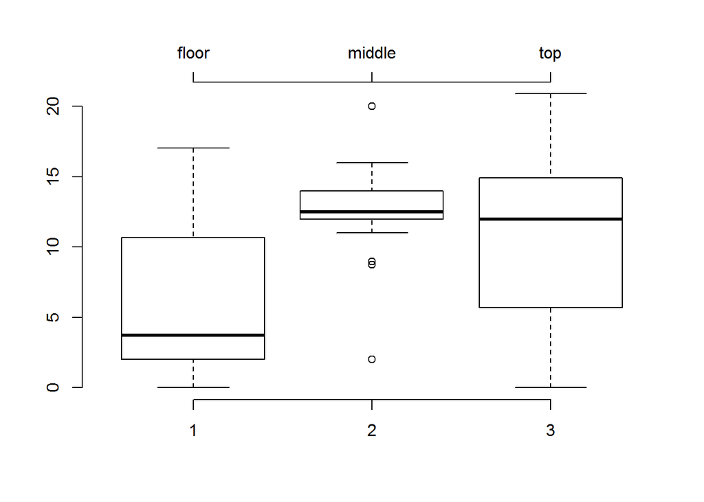

```r
# Create a boxplot of sugars by shelf value, without axes
boxplot( sugars ~ shelf, data = UScereal, axes = FALSE)

# Add a default y-axis to the left of the boxplot
axis(side = 2)


# Add an x-axis below the plot, labelled 1, 2, and 3
axis(side = 1 , at =c(1, 2, 3))

# Add a second x-axis above the plot
axis(side = 3, at = c(1, 2, 3),
     labels = c("floor", "middle", "top"))
```

### Using the supsmu() function to add smooth trend curves

As we saw in the video, some scatterplots exhibit fairly obvious trends that are not linear. In such cases, we may want to add a curved trend line that highlights this behavior of the data and the supsmu() function represents one way of doing this.

To use this function, we need to specify values for the required arguments x and y, but it also has a number of optional arguments. Here, we consider the optional bass argument, which controls the degree of smoothness in the resulting trend curve. The default value is 0, but specifying larger values (up to a maximum of 10) results in a smoother curve. This exercise asks you to use the supsmu() function to add two trend lines to a scatterplot, one using the default parameters and the other with increased smoothness.

### INSTRUCTIONS

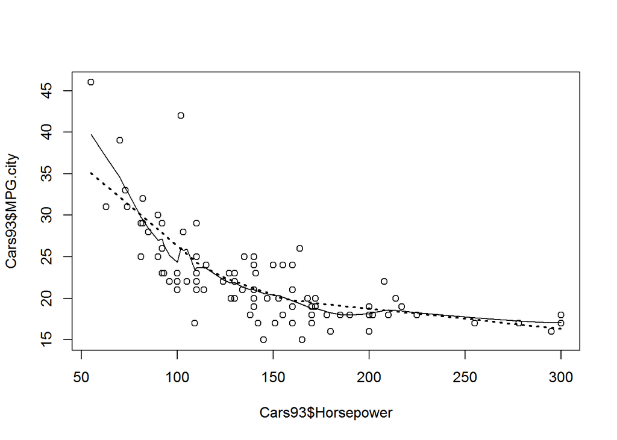

```r
# Create a scatterplot of MPG.city vs. Horsepower
plot(Cars93$Horsepower, Cars93$MPG.city)

# Call supsmu() to generate a smooth trend curve, with default bass
trend1 <- supsmu(Cars93$Horsepower, Cars93$MPG.city)

# Add this trend curve to the plot
lines(trend1, lwd =1)

# Call supsmu() for a second trend curve, with bass = 10
trend2 <- supsmu(Cars93$Horsepower, Cars93$MPG.city, bass = 10)

# Add this trend curve as a heavy, dotted line
lines(trend2,lty = 3, lwd = 2 )
```

## How much is too much?

As we have seen, base R graphics provides tremendous flexibility in creating plots with multiple lines, points of different shapes and sizes, and added text, along with arrays of multiple plots. If we attempt to add too many details to a plot or too many plots to an array, however, the result can become too complicated to be useful. This chapter focuses on how to manage this visual complexity so the results remain useful to ourselves and to others.

### Too much is too much

The first example presented in Chapter 1 applied the plot() function to a data frame, yielding an array of scatterplots with one for each pair of columns in the data frame. Thus, the number of plots in this array is equal to the square of the number of columns in the data frame.

This means that if we apply the plot() function to a data frame with many columns, we will generate an enormous array of scatterplots, each of which will be too small to be useful. The purpose of this exercise is to provide a memorable example.

### INSTRUCTIONS

Applying the plot() function to a data frame with k columns will create a k by k array of scatterplots.

Use the ncol() function to compute the number of plots in this array for the Cars93 data frame. Just print the result to the console. Call plot() on Cars93 to generate the scatterplot array. Can you verify that your calculation was correct?

```r
# Compute the number of plots to be displayed
ncol(Cars93)^2
```

```
## [1] 729
```

```r
# Plot the array of scatterplots
#plot(Cars93)
```

### Deciding how many scatterplots is too many

As noted in the video, the matplot() function can be used to easily generate a plot with several scatterplots on the same set of axes. By default, the points in these scatterplots are represented by the numbers 1 through n, where n is the total number of scatterplots included, but most of the options available with the plot() function are also possible by specifying the appropriate arguments.

This exercise asks you to set up a plot array with four of these multiple scatterplot displays, each including one more scatterplot than the previous one. The point of this exercise is to encourage you to judge for yourself how many scatterplots is too many?.

INSTRUCTIONS

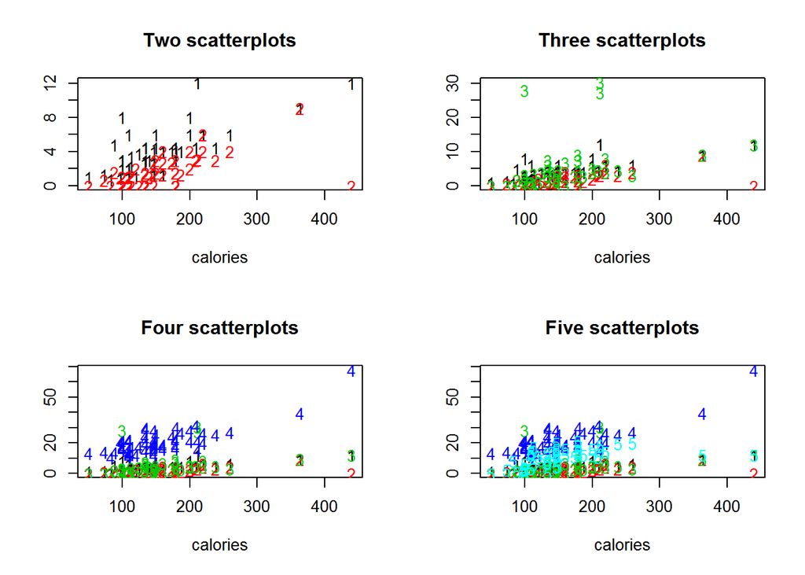

```r
# Construct the vector keep_vars
keep_vars <- c("calories", "protein", "fat",
               "fibre", "carbo", "sugars")

# Use keep_vars to extract the desired subset of UScereal
df <- UScereal[, keep_vars]

# Set up a two-by-two plot array
par(mfrow = c(2, 2))

# Use matplot() to generate an array of two scatterplots
matplot(UScereal$calories, UScereal[,c("protein", "fat")],
        xlab = "calories", ylab = "")

# Add a title
title("Two scatterplots")


# Use matplot() to generate an array of three scatterplots
matplot(UScereal$calories, UScereal[,c("protein", "fat", "fibre")],
        xlab = "calories", ylab = "")

# Add a title
title("Three scatterplots")

# Use matplot() to generate an array of four scatterplots
matplot(UScereal$calories, UScereal[,c("protein", "fat", "fibre", "carbo")], xlab = "calories", ylab = "")

# Add a title
title("Four scatterplots")

# Use matplot() to generate an array of five scatterplots
matplot(UScereal$calories, UScereal[,c("protein", "fat", "fibre", "carbo", "sugars"),], xlab = "calories", ylab = "")

# Add a title
title("Five scatterplots")
```